# Living test: `summarize_cv_results()`

Validates Phase A CV diagnostic expansion using GBSG

Author

Larry F. León

Published

April 23, 2026

# 1 Purpose

This document exercises every branch of `summarize_cv_results()` against a `forestsearch_tenfold()` run on the GBSG dataset. It is a “living” test: re-running it with an updated function should produce identical pass/fail results. A cumulative pass/fail table is rendered in Section 11.

Coverage:

1. **Minimal invocation** — `summarize_cv_results(tf)` with no optional arguments. Inspects structure of the returned object and confirms every component slot is populated.
2. **Full invocation** — with `original_sg`, `original_grf_cuts`, and `create_plots = TRUE`. Validates `original_agreement` and plot components.
3. **Input validation** — confirms the documented error conditions fire with expected messages.
4. **Backward compatibility** — simulates a pre-feature-branch object by dropping `grf_cuts` from `fold_summary`; confirms graceful NULL returns for the GRF-dependent slots.
5. **Cross-reference against manual aggregation** — reproduces `grf_cut_summary` using the `.clean_grf` + `.grf_dist` helpers lifted directly from `gbsg_10fold_dmin_sensitivity.qmd`, then asserts row-for-row equality with the function’s output.
6. **Print method** — confirms `print.fs_cv_summary()` emits the expected metadata and section headers.
7. **Phase B diagnostic columns** — confirms the new `fold_summary` columns (`pconsistency`, `training_fs_hr`, `n_candidates_evaluated`) are present, typed correctly, `NA` exactly when their semantics require it, and in valid domains. Confirms the `pconsistency_distribution` and `fold_numeric_summary` slots are populated from the columns and produce the expected row counts. Confirms backward-compatible behaviour when individual columns or the entire Phase B set are stripped.

The document uses `dmin.grf = 12, frac.tau = 0.8` (the strict baseline from `gbsg_10fold_dmin_sensitivity.qmd` config A). This setting produces a diverse mix of `{er <= 0}`, `(no subgroup)`, and non-`er` subgroups across folds, which exercises all diagnostic branches even at small simulation counts.

**Checkpoint behaviour.** This document does not cache CV results; the run executes every render. At quick-mode sims, this takes on the order of 1–2 minutes.

# 2 Setup

```r
library(forestsearch)
library(survival)
library(data.table)
library(gt)
library(ggplot2)
library(future)
library(foreach)
library(doFuture)
```

```r
# --- Simulation size -------------------------------------------------------
if (isTRUE(params$quick_mode)) {
  Ksims_cv  <- 10L
  Kfolds_cv <- 10L
  cat("Mode: quick (sims = 10).  Set quick_mode = FALSE for sims = 100.\n")
} else {
  Ksims_cv  <- 100L
  Kfolds_cv <- 10L
  cat("Mode: full (sims = 100).  Expect 15-20 min runtime.\n")
}
```

```
Mode: quick (sims = 10).  Set quick_mode = FALSE for sims = 100.
```

```r
# --- GBSG-specific parameters ---------------------------------------------
confounders.name <- c("age", "meno", "size", "grade3", "nodes", "pgr", "er")
outcome.name     <- "time_months"
event.name       <- "status"
treat.name       <- "hormon"
id.name          <- "id"

# --- forestsearch() base arguments (mirrors sensitivity QMD config A) -----
fs_args_base <- list(
  hr.threshold              = 1.25,
  hr.consistency            = 1.00,
  pconsistency.threshold    = 0.90,
  stop_threshold            = 0.95,
  sg_focus                  = "maxSG",
  max_subgroups_search      = 10L,
  use_twostage              = FALSE,
  use_grf                   = TRUE,
  return_selected_cuts_only = TRUE,
  use_lasso                 = TRUE,
  cut_type                  = "default",
  frac.tau                  = 0.8,
  dmin.grf                  = 12,
  maxk                      = 2L,
  n.min                     = 60L,
  d0.min                    = 10L,
  d1.min                    = 10L,
  fs.splits                 = 400L,
  details                   = FALSE,
  quiet                     = TRUE,
  plot.sg                   = FALSE,
  plot.grf                  = FALSE
)

# --- Parallel configuration ------------------------------------------------
n_workers <- floor(0.95 * max(1L, parallel::detectCores() - 1L))
```

```r
df              <- survival::gbsg
df$grade3       <- as.integer(df$grade == "3")
df$id           <- seq_len(nrow(df))
df$time_months  <- df$rfstime / 30.4375
```

```r
# Test-result collector.  Every test case appends a row; the final
# section renders these into a gt summary table.
test_results <- data.frame(
  Section = character(0),
  Test    = character(0),
  Status  = character(0),
  Detail  = character(0),
  stringsAsFactors = FALSE
)

.tc <- function(section, test, pass, detail = "") {
  status <- if (isTRUE(pass)) "PASS" else "FAIL"
  new_row <- data.frame(
    Section = section,
    Test    = test,
    Status  = status,
    Detail  = substr(detail, 1L, 120L),
    stringsAsFactors = FALSE
  )
  # Append to parent scope
  test_results <<- rbind(test_results, new_row)
  invisible(pass)
}

.expect_error <- function(section, test, expr, pattern) {
  err_msg <- NULL
  tryCatch(
    eval(expr),
    error = function(e) { err_msg <<- conditionMessage(e) }
  )
  pass   <- !is.null(err_msg) && grepl(pattern, err_msg, fixed = FALSE)
  detail <- if (!is.null(err_msg)) err_msg else "<no error thrown>"
  .tc(section, test, pass, detail)
}
```

# 3 Baseline runs

## 3.1 Full-data ForestSearch (always runs)

```r
fs_full <- do.call(forestsearch, c(list(
  df.analysis      = df,
  confounders.name = confounders.name,
  outcome.name     = outcome.name,
  event.name       = event.name,
  treat.name       = treat.name,
  id.name          = id.name,
  parallel_args    = list(plan         = "multisession",
                          workers      = n_workers,
                          show_message = FALSE)
), fs_args_base))
plan("sequential")

cat("Full-data identified subgroup:",
    paste(fs_full$sg.harm, collapse = " & "), "\n")
```

```
Full-data identified subgroup: {er <= 0}
```

```r
cat("Full-data GRF cuts:         ",
    paste(fs_full$grf_cuts, collapse = " | "), "\n")
```

```
Full-data GRF cuts:          er <= 0
```

## 3.2 10-fold CV

```r
.run_cv <- function() {
  t0 <- proc.time()
  out <- forestsearch_tenfold(
    fs.est        = fs_full,
    sims          = Ksims_cv,
    Kfolds        = Kfolds_cv,
    details       = FALSE,
    keep_resCV    = FALSE,
    parallel_args = list(plan         = "multisession",
                         workers      = n_workers,
                         show_message = FALSE)
  )
  plan("sequential")
  attr(out, "runtime_seconds") <-
    as.numeric((proc.time() - t0)["elapsed"])
  out
}

message(sprintf("Running %d-sim x %d-fold CV ...",
                Ksims_cv, Kfolds_cv))
tf <- .run_cv()

cat(sprintf("CV completed: %d sims x %d folds = %d sim x fold pairs\n",
            tf$sims, tf$Kfolds, nrow(tf$fold_summary)))
```

```
CV completed: 10 sims x 10 folds = 100 sim x fold pairs
```

```r
cat(sprintf("fold_summary columns: %s\n",
            paste(names(tf$fold_summary), collapse = ", ")))
```

```
fold_summary columns: sim, fold, n_test, sg1, sg2, grf_cuts, pconsistency, training_fs_hr, n_candidates_evaluated, any_found
```

```r
.tc("Baseline", "fold_summary has required columns",
    all(c("sim", "fold", "sg1", "sg2", "any_found") %in%
          names(tf$fold_summary)),
    detail = paste(names(tf$fold_summary), collapse = ", "))

.tc("Baseline", "fold_summary$grf_cuts present",
    "grf_cuts" %in% names(tf$fold_summary),
    detail = "Required for feature-branch diagnostic slots")

.tc("Baseline", "fold_summary$pconsistency present",
    "pconsistency" %in% names(tf$fold_summary),
    detail = "Required for Phase B pconsistency_distribution slot")

.tc("Baseline", "fold_summary$training_fs_hr present",
    "training_fs_hr" %in% names(tf$fold_summary),
    detail = "Phase B diagnostic column")

.tc("Baseline", "fold_summary$n_candidates_evaluated present",
    "n_candidates_evaluated" %in% names(tf$fold_summary),
    detail = "Phase B diagnostic column")
```

# 4 Test 1: Minimal invocation

Calls `summarize_cv_results(tf)` with no optional arguments. Every slot should be populated except `original_agreement` and `plots` (which require opt-in).

```r
cv_diag <- summarize_cv_results(tf)

# Top-level slots
slot_status <- list(
  identification_summary    = !is.null(cv_diag$identification_summary),
  grf_cut_summary           = !is.null(cv_diag$grf_cut_summary),
  cut_vs_subgroup_xtab      = !is.null(cv_diag$cut_vs_subgroup_xtab),
  no_subgroup_decomposition = !is.null(cv_diag$no_subgroup_decomposition),
  original_agreement        = is.null(cv_diag$original_agreement),
  metrics_table             = !is.null(cv_diag$metrics_table),
  plots                     = is.null(cv_diag$plots)
)

for (nm in names(slot_status)) {
  expected_populated <- !grepl("^(original_agreement|plots)$", nm)
  observed_populated <- if (grepl("^(original_agreement|plots)$", nm)) {
    !slot_status[[nm]]
  } else {
    slot_status[[nm]]
  }
  .tc("Test 1: minimal",
      sprintf("slot %s matches expectation", nm),
      isTRUE(slot_status[[nm]]),
      detail = sprintf("populated = %s", observed_populated))
}

# Metadata
.tc("Test 1: minimal", "n_sims matches tf$sims",
    cv_diag$n_sims == tf$sims,
    detail = sprintf("obs=%d exp=%d", cv_diag$n_sims, tf$sims))
.tc("Test 1: minimal", "n_folds matches tf$Kfolds",
    cv_diag$n_folds == tf$Kfolds,
    detail = sprintf("obs=%d exp=%d", cv_diag$n_folds, tf$Kfolds))
.tc("Test 1: minimal", "total_pairs matches nrow(fold_summary)",
    cv_diag$total_pairs == nrow(tf$fold_summary),
    detail = sprintf("obs=%d exp=%d",
                     cv_diag$total_pairs, nrow(tf$fold_summary)))
.tc("Test 1: minimal", "has_grf_cuts == TRUE (feature branch)",
    isTRUE(cv_diag$has_grf_cuts))
.tc("Test 1: minimal", "class == 'fs_cv_summary'",
    inherits(cv_diag, "fs_cv_summary"))

# Raw data structure
.tc("Test 1: minimal", "$data$identification is data.frame",
    is.data.frame(cv_diag$data$identification))
.tc("Test 1: minimal", "$data$grf_cuts is data.frame",
    is.data.frame(cv_diag$data$grf_cuts))
.tc("Test 1: minimal", "identification df has expected columns",
    all(c("Rank", "Subgroup", "n_folds", "pct_folds") %in%
          names(cv_diag$data$identification)))
.tc("Test 1: minimal", "grf_cuts df has expected columns",
    all(c("Rank", "grf_cut", "n_folds", "pct_folds") %in%
          names(cv_diag$data$grf_cuts)))

# Row-count sanity.  When top_n truncates, an "(N others)" row
# aggregates the tail; the n_folds column must still sum to total_pairs.
total_expected <- nrow(tf$fold_summary)
total_id       <- sum(cv_diag$data$identification$n_folds)
.tc("Test 1: minimal",
    "identification n_folds sums to total pairs (including (N others))",
    total_id == total_expected,
    detail = sprintf("obs=%d exp=%d", total_id, total_expected))

total_grf <- sum(cv_diag$data$grf_cuts$n_folds)
.tc("Test 1: minimal",
    "grf_cuts n_folds sums to total pairs (including (N others))",
    total_grf == total_expected,
    detail = sprintf("obs=%d exp=%d", total_grf, total_expected))

# If the "(N others)" row is present, it should carry the tail count.
id_has_others  <- any(grepl("^\\(\\d+ others\\)$",
                            cv_diag$data$identification$Subgroup))
grf_has_others <- any(grepl("^\\(\\d+ others\\)$",
                            cv_diag$data$grf_cuts$grf_cut))
.tc("Test 1: minimal", "identification_summary row count <= top_n + 1",
    nrow(cv_diag$data$identification) <= 16L,
    detail = sprintf("rows=%d; has (N others) row=%s",
                     nrow(cv_diag$data$identification), id_has_others))
.tc("Test 1: minimal", "grf_cut_summary row count <= top_n + 1",
    nrow(cv_diag$data$grf_cuts) <= 16L,
    detail = sprintf("rows=%d; has (N others) row=%s",
                     nrow(cv_diag$data$grf_cuts), grf_has_others))
```

## 4.1 Rendered gt tables from minimal invocation

### 4.1.1 Identification summary

```r
cv_diag$identification_summary
```

**Identified subgroups across sim x fold pairs**

10 simulations x 10 folds = 100 total pairs

| Rank | Identified subgroup | n folds | % folds |
| --- | --- | --- | --- |
| 1 | {er <= 0} | 48 | 48.00 |
| 2 | (no subgroup) | 21 | 21.00 |
| 3 | !{age <= 43} & {age <= 47} | 10 | 10.00 |
| 4 | {age <= 47} & !{age <= 43} | 5 | 5.00 |
| 5 | {age <= 48} & !{age <= 43} | 5 | 5.00 |
| 6 | !{age <= 43} & {age <= 48} | 3 | 3.00 |
| 7 | {age <= 50} & !{age <= 43} | 2 | 2.00 |
| 8 | !{size <= 25} & {er <= 8} | 1 | 1.00 |
| 9 | {er <= 0} & {pgr <= 32} | 1 | 1.00 |
| 10 | {er <= 0} & {pgr <= 34.5} | 1 | 1.00 |
| 11 | {er <= 0} & {pgr <= 34} | 1 | 1.00 |
| 12 | {er <= 8} & !{size <= 25} | 1 | 1.00 |
| 13 | {grade3} & {pgr <= 8} | 1 | 1.00 |

### 4.1.2 GRF cut summary

```r
cv_diag$grf_cut_summary
```

**GRF cuts across training sets**

Raw grf_cuts strings; 10 simulations x 10 folds = 100 total pairs

| Rank | GRF cuts | n folds | % folds |
| --- | --- | --- | --- |
| 1 | er <= 0 | 41 | 41.00 |
| 2 | age <= 48 \| age <= 43 \| er <= 0 | 15 | 15.00 |
| 3 | age <= 47 \| age <= 43 \| er <= 0 | 12 | 12.00 |
| 4 | (no GRF cut) | 10 | 10.00 |
| 5 | age <= 50 \| age <= 43 \| er <= 0 | 7 | 7.00 |
| 6 | age <= 47 \| age <= 43 \| er <= 369 | 2 | 2.00 |
| 7 | age <= 48 \| age <= 44 \| er <= 0 | 2 | 2.00 |
| 8 | age <= 48 \| age <= 45 \| er <= 0 | 2 | 2.00 |
| 9 | age <= 50 \| age <= 44 \| er <= 0 | 2 | 2.00 |
| 10 | age <= 47 \| age <= 43 \| size <= 14 | 1 | 1.00 |
| 11 | age <= 47 \| age <= 44 \| er <= 0 | 1 | 1.00 |
| 12 | age <= 48 \| age <= 43 \| er <= 369 | 1 | 1.00 |
| 13 | age <= 48 \| age <= 43 \| size <= 19 | 1 | 1.00 |
| 14 | age <= 49 \| age <= 43 \| er <= 0 | 1 | 1.00 |
| 15 | age <= 49 \| age <= 45 \| er <= 317 | 1 | 1.00 |
| 16 | (1 others) | 1 | 1.00 |

### 4.1.3 Cut × subgroup cross-tab

```r
cv_diag$cut_vs_subgroup_xtab
```

**GRF cut x identified subgroup**

Cross-tabulation across 100 sim x fold pairs

| GRF cuts | Identified subgroup | n folds | % folds |
| --- | --- | --- | --- |
| er <= 0 | {er <= 0} | 35 | 35.00 |
| age <= 47 \| age <= 43 \| er <= 0 | !{age <= 43} & {age <= 47} | 9 | 9.00 |
| (no GRF cut) | (no subgroup) | 9 | 9.00 |
| age <= 48 \| age <= 43 \| er <= 0 | {er <= 0} | 5 | 5.00 |
| er <= 0 | (no subgroup) | 4 | 4.00 |
| age <= 48 \| age <= 43 \| er <= 0 | {age <= 48} & !{age <= 43} | 4 | 4.00 |
| age <= 48 \| age <= 43 \| er <= 0 | !{age <= 43} & {age <= 48} | 3 | 3.00 |
| age <= 47 \| age <= 43 \| er <= 0 | {age <= 47} & !{age <= 43} | 3 | 3.00 |
| age <= 48 \| age <= 43 \| er <= 0 | (no subgroup) | 2 | 2.00 |
| age <= 50 \| age <= 43 \| er <= 0 | {age <= 50} & !{age <= 43} | 2 | 2.00 |
| age <= 50 \| age <= 43 \| er <= 0 | {er <= 0} | 2 | 2.00 |
| age <= 47 \| age <= 43 \| er <= 369 | !{age <= 43} & {age <= 47} | 1 | 1.00 |
| er <= 0 | !{size <= 25} & {er <= 8} | 1 | 1.00 |
| age <= 48 \| age <= 43 \| size <= 19 | (no subgroup) | 1 | 1.00 |
| age <= 48 \| age <= 44 \| er <= 0 | (no subgroup) | 1 | 1.00 |
| (18 others) | (18 others) | 18 | 18.00 |

Rows where the identified subgroup does not align with GRF's output reveal divergence between candidate discovery and consistency evaluation.

### 4.1.4 No-subgroup decomposition

```r
cv_diag$no_subgroup_decomposition
```

**Decomposition of no-subgroup folds**

Out of 100 sim x fold pairs

| Category | n folds | % of all pairs | % of no-sg folds |
| --- | --- | --- | --- |
| Folds with no subgroup identified | 21 | 21.00 | 100.00 |
| GRF returned no cut | 9 | 9.00 | 42.86 |
| GRF returned a cut; consistency rejected | 12 | 12.00 | 57.14 |

Guidance: a high 'GRF returned no cut' share argues for relaxing dmin.grf; a high 'consistency rejected' share argues for relaxing pconsistency.threshold.

### 4.1.5 Metrics table (delegated to `cv_metrics_tables()`)

```r
cv_diag$metrics_table
```

**Cross-Validation Metrics**

Subgroup: Identified Subgroup

| Metric | Description | Value (%) |
| --- | --- | --- |
| Agreement |  |  |
| Sensitivity (H) | Agreement rate for subgroup H | 53.7 |
| Sensitivity (Hc) | Agreement rate for complement Hc | 95.0 |
| PPV (H) | Positive predictive value for H | 58.1 |
| PPV (Hc) | Positive predictive value for Hc | 93.8 |
| Subgroup Finding |  |  |
| Any Found | Any subgroup identified | 80.0 |
| Exact Match | Exact match on all factors | 50.0 |
| At Least 1 | At least one factor matches | 50.0 |
| Cov1 Any | First covariate found (any cut) | 50.0 |
| Cov2 Any | Second covariate found (any cut) | NA |
| Cov1 & Cov2 | Both covariates found | 0.0 |
| Cov1 Exact | First covariate exact match | 50.0 |
| Cov2 Exact | Second covariate exact match | NA |

Based on 10 simulation(s) with 10-fold CV. Values are medians shown as percentages.

# 5 Test 2: Full invocation with originals and plots

```r
cv_diag_full <- summarize_cv_results(
  cv_output         = tf,
  original_sg       = fs_full$sg.harm,
  original_grf_cuts = fs_full$grf_cuts,
  create_plots      = TRUE
)

.tc("Test 2: full", "$original_agreement populated",
    !is.null(cv_diag_full$original_agreement))
.tc("Test 2: full", "$plots populated",
    !is.null(cv_diag_full$plots))
.tc("Test 2: full", "$plots$identification is ggplot",
    inherits(cv_diag_full$plots$identification, "ggplot"))
.tc("Test 2: full", "$plots$grf_cut is ggplot (has_grf_cuts TRUE)",
    inherits(cv_diag_full$plots$grf_cut, "ggplot"))

# original_agreement raw data structure
oa_df <- cv_diag_full$data$original_agreement
.tc("Test 2: full", "original_agreement df has Metric, Value",
    all(c("Metric", "Value") %in% names(oa_df)))
.tc("Test 2: full", "original_agreement includes Exact subgroup match row",
    any(grepl("Exact subgroup match", oa_df$Metric)))
.tc("Test 2: full", "original_agreement includes Exact GRF-cut match row",
    any(grepl("Exact GRF-cut match", oa_df$Metric)))
.tc("Test 2: full", "original_agreement includes Both match row",
    any(grepl("Both subgroup and GRF cut match", oa_df$Metric)))
```

## 5.1 Rendered original agreement table

```r
cv_diag_full$original_agreement
```

**Agreement with original full-data analysis**

Fraction of sim x fold pairs matching the original result

|  | Value |
| --- | --- |
| Total sim x fold pairs | 100 |
| Original subgroup definition | {er <= 0} |
| Exact subgroup match | 48 (48.0%) |
| Partial match (>=1 shared factor) | 51 (51.0%) |
| Original GRF cut(s) | er <= 0 |
| Exact GRF-cut match | 41 (41.0%) |
| Both subgroup and GRF cut match | 35 (35.0%) |

## 5.2 Rendered plots

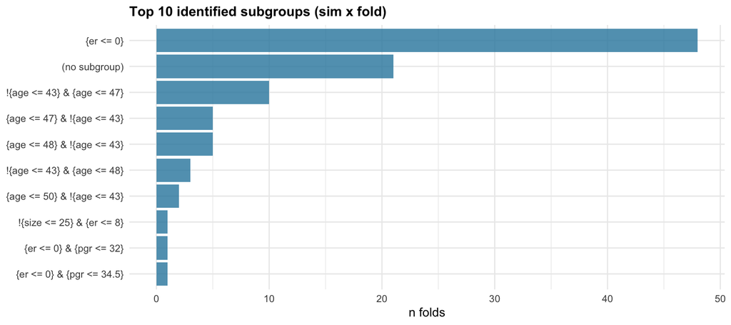

```r
cv_diag_full$plots$identification
```

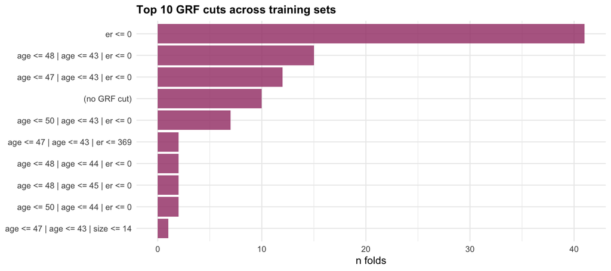

```r
cv_diag_full$plots$grf_cut
```

# 6 Test 3: Input validation

Confirms each documented error condition fires with the expected message pattern.

```r
# Case 3.1: non-list input
.expect_error(
  "Test 3: errors", "non-list input rejected",
  expr    = quote(summarize_cv_results(cv_output = "not a list")),
  pattern = "must be a list"
)

# Case 3.2: empty fold_summary
tf_empty <- tf
tf_empty$fold_summary <- tf$fold_summary[0, , drop = FALSE]
.expect_error(
  "Test 3: errors", "empty fold_summary rejected",
  expr    = quote(summarize_cv_results(cv_output = tf_empty)),
  pattern = "missing or empty"
)

# Case 3.3: missing required column
tf_bad <- tf
tf_bad$fold_summary$sg1 <- NULL
.expect_error(
  "Test 3: errors", "missing required column rejected",
  expr    = quote(summarize_cv_results(cv_output = tf_bad)),
  pattern = "missing required column"
)

# Case 3.4: bad top_n
.expect_error(
  "Test 3: errors", "non-positive top_n rejected",
  expr    = quote(summarize_cv_results(cv_output = tf, top_n = 0)),
  pattern = "positive integer"
)

# Case 3.5: fs_kfold redirection
# We synthesise a minimal fs_kfold object with the right class; it must
# emit the pointer to cv_summary_tables()/cv_metrics_tables().
tf_kfold_fake <- structure(
  list(fold_summary = tf$fold_summary),
  class = c("fs_kfold", "list")
)
.expect_error(
  "Test 3: errors", "fs_kfold object redirected",
  expr    = quote(summarize_cv_results(cv_output = tf_kfold_fake)),
  pattern = "cv_summary_tables|cv_metrics_tables"
)
```

# 7 Test 4: Backward compatibility

Drops `grf_cuts` from `fold_summary` to simulate a pre-feature-branch object. Expects graceful NULL for the GRF-dependent slots and a populated `identification_summary`.

```r
tf_nogrf <- tf
tf_nogrf$fold_summary <- tf$fold_summary[
  , setdiff(names(tf$fold_summary), "grf_cuts"),
  drop = FALSE
]

cv_diag_nogrf <- summarize_cv_results(tf_nogrf)

.tc("Test 4: backward-compat", "has_grf_cuts FALSE",
    isFALSE(cv_diag_nogrf$has_grf_cuts))
.tc("Test 4: backward-compat", "identification_summary populated",
    !is.null(cv_diag_nogrf$identification_summary))
.tc("Test 4: backward-compat", "grf_cut_summary NULL",
    is.null(cv_diag_nogrf$grf_cut_summary))
.tc("Test 4: backward-compat", "cut_vs_subgroup_xtab NULL",
    is.null(cv_diag_nogrf$cut_vs_subgroup_xtab))
.tc("Test 4: backward-compat", "no_subgroup_decomposition NULL",
    is.null(cv_diag_nogrf$no_subgroup_decomposition))
.tc("Test 4: backward-compat", "$data$grf_cuts NULL",
    is.null(cv_diag_nogrf$data$grf_cuts))
.tc("Test 4: backward-compat", "metrics_table still populated",
    !is.null(cv_diag_nogrf$metrics_table))
```

# 8 Test 5: Cross-reference against manual aggregation

Reproduces `grf_cut_summary` and `identification_summary` using the `.clean_grf` + `.grf_dist` + `.build_sg_full` helpers lifted directly from `gbsg_10fold_dmin_sensitivity.qmd`, then asserts row-for-row equality with the function output. This is the refactor-safety check: the function should produce identical results to the manual one-off aggregation the sensitivity QMD performed.

To isolate the tabulation logic from the top-n truncation layer, this test calls `summarize_cv_results(..., top_n = Inf)` so the function returns the full frequency distribution without an `"(N others)"` aggregation row. The row-sum invariant under truncation is covered separately in Test 1.

```r
# Untruncated variant for byte-exact comparison
cv_diag_full_topn <- summarize_cv_results(tf, top_n = Inf)
```

```r
# Lifted verbatim from gbsg_10fold_dmin_sensitivity.qmd
.clean_grf_manual <- function(x) {
  if (is.na(x) || x == "") return("(no GRF cut)")
  x
}

.grf_dist_manual <- function(fsum, top_n = Inf) {
  cuts <- vapply(fsum$grf_cuts, .clean_grf_manual, character(1))
  tab  <- as.data.frame(table(cuts = cuts), stringsAsFactors = FALSE)
  tab  <- tab[order(-tab$Freq), , drop = FALSE]
  if (is.finite(top_n) && nrow(tab) > top_n) tab <- utils::head(tab, top_n)
  tab
}

.build_sg_full_manual <- function(fsum) {
  ifelse(
    is.na(fsum$sg1),
    "(no subgroup)",
    ifelse(
      is.na(fsum$sg2),
      fsum$sg1,
      paste(fsum$sg1, fsum$sg2, sep = " & ")
    )
  )
}
```

```r
# Manual (no truncation)
manual_grf <- .grf_dist_manual(tf$fold_summary)
manual_grf_aligned <- data.frame(
  grf_cut = as.character(manual_grf$cuts),
  n_folds = as.integer(manual_grf$Freq),
  stringsAsFactors = FALSE
)
rownames(manual_grf_aligned) <- NULL

# Function (untruncated)
fn_grf <- cv_diag_full_topn$data$grf_cuts
fn_grf_aligned <- data.frame(
  grf_cut = fn_grf$grf_cut,
  n_folds = as.integer(fn_grf$n_folds),
  stringsAsFactors = FALSE
)
rownames(fn_grf_aligned) <- NULL

# Same number of rows?
.tc("Test 5: cross-ref", "grf_cut_summary row count matches manual",
    nrow(manual_grf_aligned) == nrow(fn_grf_aligned),
    detail = sprintf("manual=%d fn=%d",
                     nrow(manual_grf_aligned),
                     nrow(fn_grf_aligned)))

# Row-for-row equality
eq_ok <- isTRUE(all.equal(manual_grf_aligned, fn_grf_aligned))
.tc("Test 5: cross-ref", "grf_cut_summary rows match manual exactly",
    eq_ok,
    detail = if (eq_ok) "all.equal TRUE" else
      paste(utils::capture.output(
        all.equal(manual_grf_aligned, fn_grf_aligned)
      ), collapse = "; "))
```

```r
# Manual identification tabulation (no truncation)
manual_sg <- .build_sg_full_manual(tf$fold_summary)
tab <- as.data.frame(table(Subgroup = manual_sg),
                     stringsAsFactors = FALSE)
tab <- tab[order(-tab$Freq), , drop = FALSE]

manual_id_aligned <- data.frame(
  Subgroup = as.character(tab$Subgroup),
  n_folds  = as.integer(tab$Freq),
  stringsAsFactors = FALSE
)
rownames(manual_id_aligned) <- NULL

fn_id <- cv_diag_full_topn$data$identification
fn_id_aligned <- data.frame(
  Subgroup = fn_id$Subgroup,
  n_folds  = as.integer(fn_id$n_folds),
  stringsAsFactors = FALSE
)
rownames(fn_id_aligned) <- NULL

.tc("Test 5: cross-ref", "identification_summary row count matches manual",
    nrow(manual_id_aligned) == nrow(fn_id_aligned),
    detail = sprintf("manual=%d fn=%d",
                     nrow(manual_id_aligned),
                     nrow(fn_id_aligned)))

eq_ok <- isTRUE(all.equal(manual_id_aligned, fn_id_aligned))
.tc("Test 5: cross-ref", "identification_summary rows match manual exactly",
    eq_ok,
    detail = if (eq_ok) "all.equal TRUE" else
      paste(utils::capture.output(
        all.equal(manual_id_aligned, fn_id_aligned)
      ), collapse = "; "))
```

```r
# Manual no-subgroup count
manual_no_sg <- sum(manual_sg == "(no subgroup)")
# Function
fn_no_sg <- cv_diag$data$no_subgroup$n_folds[
  cv_diag$data$no_subgroup$Category == "Folds with no subgroup identified"
]

.tc("Test 5: cross-ref", "no_subgroup total matches manual",
    isTRUE(manual_no_sg == fn_no_sg),
    detail = sprintf("manual=%d fn=%d", manual_no_sg, fn_no_sg))

# Manual GRF-none-among-no-sg count
manual_grf_none_in_no_sg <- sum(
  (manual_sg == "(no subgroup)") &
    vapply(tf$fold_summary$grf_cuts, .clean_grf_manual,
           character(1)) == "(no GRF cut)"
)
fn_grf_none_in_no_sg <- cv_diag$data$no_subgroup$n_folds[
  cv_diag$data$no_subgroup$Category == "  GRF returned no cut"
]

.tc("Test 5: cross-ref", "decomposition 'GRF none' matches manual",
    isTRUE(manual_grf_none_in_no_sg == fn_grf_none_in_no_sg),
    detail = sprintf("manual=%d fn=%d",
                     manual_grf_none_in_no_sg, fn_grf_none_in_no_sg))
```